# homework-number-5

Natalie Robinson

November 17, 2017

# Homework 5

## Bootstrapping Standard Errors and CIs for Linear Models

** 1. Using the “KamilarAndCooperData.csv” dataset, run a linear regression looking at log(HomeRange_km2) in relation to log(Body_mass_female_mean) and report your β coeffiecients (slope and intercept). **

```r
# to load the dataset
library(curl)
f <- curl("https://raw.githubusercontent.com/fuzzyatelin/fuzzyatelin.github.io/master/AN597_Fall17/KamilarAndCooperData.csv")
d <- read.csv(f, header = TRUE, sep = ",", stringsAsFactors = TRUE)
head(d)
```

```
##               Scientific_Name          Family          Genus      Species
## 1 Allenopithecus_nigroviridis Cercopithecidae Allenopithecus nigroviridis
## 2         Allocebus_trichotis Cercopithecidae      Allocebus    trichotis
## 3           Alouatta_belzebul        Atelidae       Alouatta     belzebul
## 4             Alouatta_caraya        Atelidae       Alouatta       caraya
## 5            Alouatta_guariba        Atelidae       Alouatta      guariba
## 6           Alouatta_palliata        Atelidae       Alouatta     palliata
##   Brain_Size_Species_Mean Brain_Size_Female_Mean   Brain_size_Ref
## 1                   58.02                  53.70 Isler et al 2008
## 2                      NA                     NA
## 3                   52.84                  51.19 Isler et al 2008
## 4                   52.63                  47.80 Isler et al 2008
## 5                   51.70                  49.08 Isler et al 2008
## 6                   49.88                  48.04 Isler et al 2008
##   Body_mass_male_mean Body_mass_female_mean Mass_Dimorphism
```

[output cut: 69 more lines]

```r
# to run a linear regression
m <- lm(data = d, log(HomeRange_km2) ~ log(Body_mass_female_mean))
m
```

```
##
## Call:
## lm(formula = log(HomeRange_km2) ~ log(Body_mass_female_mean),
##     data = d)
##
## Coefficients:
##                (Intercept)  log(Body_mass_female_mean)
##                     -9.441                       1.036
```

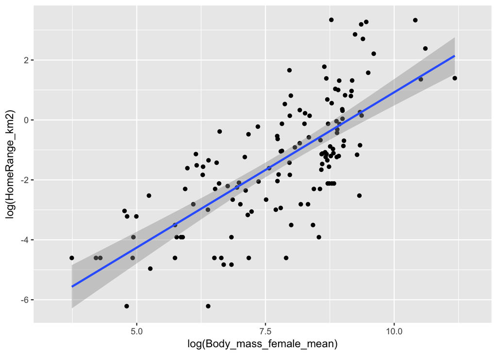

```r
library(ggplot2)
g <- ggplot(data = d, aes(x= log(Body_mass_female_mean), y = log(HomeRange_km2)))
g <- g + geom_point()
g <- g + geom_smooth(method = "lm")
g
```

The slope is 1.036 and the intercept is -9.441

** 2. Then, use bootstrapping to sample from your data 1000 times with replacement, each time fitting the same model and calculating the same coefficients. This generates a sampling distribution for each β coefficient. **

```r
set <- data.frame(NULL) # sets up a dummy variable to hold our 1000 simulations
n <- 213 # there are 213 entries in the Kalimar and Cooper dataset
for (i in 1:1000) { # simulate 1000 times
  sample <- d[sample(nrow(d), n, replace = TRUE), ]
  m <- lm(log(HomeRange_km2) ~ log(Body_mass_female_mean), data = sample) # fitting the same model each time
  coef <- m$coefficients # get the simulated intercepts and slopes
  set <- rbind(set, coef) # make a dataframe to hold the simulated intercepts and slopes
}
colnames(set) <- c("Intercept", "Slope")
head(set)
```

```
##   Intercept     Slope
## 1 -9.848275 1.0865476
## 2 -8.825484 0.9536315
## 3 -9.675417 1.0518450
## 4 -9.331625 1.0155880
## 5 -9.628804 1.0432866
## 6 -8.956579 0.9679059
```

```r
# this generates a sampling distribution for each B coefficient
```

- Estimate the standard error for each of your β coefficients as the standard deviation of the sampling distribution from your bootstrap and determine the 95% CI for each of your β coefficients based on the appropriate quantiles from your sampling distribution.

```r
df <- data.frame(cbind(sd(set$Intercept), sd(set$Slope), quantile(set$Intercept, 0.025), quantile(set$Intercept, 0.975), quantile(set$Slope, 0.025), quantile(set$Slope, 0.975)))
colnames(df) <- c("SE_Intercept", "SE_Slope", "LowerCI_Intercept", "UpperCI_Intercept", "LowerCI_Slope", "UpperCI_Slope")
df
```

```
##      SE_Intercept   SE_Slope LowerCI_Intercept UpperCI_Intercept
## 2.5%    0.6164624 0.07977601         -10.81357         -8.353454
##      LowerCI_Slope UpperCI_Slope
## 2.5%     0.8850131      1.202064
```

- How does the former compare to the SE estimated from your entire dataset using the formula for standard error implemented in lm()?

```r
summary(m)$coef # to find the SE of the entire dataset
```

```
##                             Estimate Std. Error   t value     Pr(>|t|)
## (Intercept)                -9.829202 0.60644785 -16.20783 4.237477e-33
## log(Body_mass_female_mean)  1.059565 0.07688148  13.78180 2.916334e-27
```

- How does the latter compare to the 95% CI estimated from your entire dataset?

```r
confint(m, level = 0.95)
```

```
##                                  2.5 %    97.5 %
## (Intercept)                -11.0289009 -8.629504
## log(Body_mass_female_mean)   0.9074754  1.211655
```

## Extra Credit Part 1

** Write a FUNCTION that takes as its arguments a dataframe, “d”, a linear model, “m” (as a character string, e.g., “logHR~logBM”), a user-defined confidence interval level, “conf.level” (with default = 0.95), and a number of bootstrap replicates, “n” (with default = 1000). Your function should return a dataframe that includes: beta coefficient names; beta coefficients, standard errors, and upper and lower CI limits for the linear model based on your entire dataset; and mean beta coefficient estimates, SEs, and CI limits for those coefficients based on your bootstrap. **

d = dataframe m = linear model conf.level = user-define confidence interval level (default = 0.95) n = number of bootstrap replicates (default = 1000)

```r
bootstrap <- function(d, m, conf.level = 0.95, n = 1000) {

  # beta coefficients and SE based on entire dataset
  summary_m <- coef(summary(m))
  beta_coef_names <- c("beta0", "beta1")
  beta_coefs <- summary_m[ ,1]
  SE <- summary_m[ ,2]

  # CI based on entire dataset
  lowerCI <- confint(m, level = conf.level)[ ,1]
  upperCI <- confint(m, level = conf.level)[ ,2]

  # Bootstrapping (modified from part 2)
  set <- data.frame(NULL) # sets up a dummy variable to hold simulations
  for (i in 1:n) { # simulate n times
    sample <- d[sample(nrow(d), n, replace = TRUE), ]
    m <- lm(m, data = d) # fitting the same model each time
    coef <- m$coefficients # get the simulated intercepts and slopes
    set <- rbind(set, coef) # make a dataframe to hold the simulated intercepts and slopes
  }

  # Mean beta coefficients based on bootstrap
  intercepts <- as.numeric(c(set$Intercept))
  mean_intercept <- mean(intercepts)

  slopes <- as.numeric(c(set$Slopes))
  mean_slope <- mean(slopes)

  # SE and CI based on bootstrap (from part 2)
  df <- data.frame(cbind(sd(set$Intercept), sd(set$Slope), quantile(set$Intercept, 0.025), quantile(set$Intercept, 0.975), quantile(set$Slope, 0.025), quantile(set$Slope, 0.975)))
colnames(df) <- c("SE_Intercept", "SE_Slope", "LowerCI_Intercept", "UpperCI_Intercept", "LowerCI_Slope", "UpperCI_Slope")

  return <- data.frame(beta_coef_names, beta_coefs, SE, lowerCI, upperCI, mean_intercept, mean_slope, df)
  return
}
```

Plugging back in data from this homework to test the function:

```r
library(curl)
f <- curl("https://raw.githubusercontent.com/fuzzyatelin/fuzzyatelin.github.io/master/AN597_Fall17/KamilarAndCooperData.csv")

d <- read.csv(f, header = TRUE, sep = ",", stringsAsFactors = TRUE)
m <- lm(data = d, log(HomeRange_km2) ~ log(Body_mass_female_mean))
conf.level <- 0.95
n <- 1000

bootstrap(d, m, conf.level = 0.95, n = 1000)
```

```
##                            beta_coef_names beta_coefs         SE
## (Intercept)                          beta0  -9.441231 0.67293459
## log(Body_mass_female_mean)           beta1   1.036432 0.08487709
##                                lowerCI   upperCI mean_intercept mean_slope
## (Intercept)                -10.7720889 -8.110374            NaN        NaN
## log(Body_mass_female_mean)   0.8685707  1.204292            NaN        NaN
##                            SE_Intercept SE_Slope LowerCI_Intercept
## (Intercept)                          NA       NA                NA
## log(Body_mass_female_mean)           NA       NA                NA
##                            UpperCI_Intercept LowerCI_Slope UpperCI_Slope
## (Intercept)                               NA            NA            NA
## log(Body_mass_female_mean)                NA            NA            NA
```

This is not working correctly. I’m not sure why the values from the boostrap are not showing up.

## Extra Credit Part 2

** Graph each beta value from the linear model and its corresponding mean value, lower CI and upper CI from a bootstrap as a function of number of bootstraps from 10 to 200 by 10s. HINT: the beta value from the linear model will be the same for all bootstraps and the mean beta value may not differ that much! **

```r
# beta coefficients based on entire dataset
summary_m <- coef(summary(m))
beta_coefs <- summary_m[ ,1]

set <- data.frame(NULL)

for (i in seq(from = 10, to = 200, by = 10)) {
  # finish this
}

g <- ggplot(data = set, aes(x = beta_coefs, y = mean_value))
```

I need to work on this more